# DNN speech recognizer

###### The capstone project of NLP Engineer offered by Udacity

In this project, I built an Automatic Speech Recognition (ASR) pipeline with the open-source dataset Libri Speech. Speech Recognition is historically a challenging task in Artificial Intelligence due to the noise and ambiguity in the speech. I invoked Mel Frequency Cepstral Coefficients (MFCC) to extract features from raw audio signals in order to reduce the dimensionality and noise caused by environmental factors. I implemented different Deep Neural Networks (DNN) models to compare the performance, and trained them with the Connectionist Temporal Classification (CTC) loss function to address the variable length of the same word in speech.

## Introduction

I build a deep neural network that functions as part of an end-to-end automatic speech recognition (ASR) pipeline! My completed pipeline will accept raw audio as input and return a predicted transcription of the spoken language. The full pipeline is summarized in the figure below.

[figure not shown]

- **STEP 1** is a pre-processing step that converts raw audio to one of two feature representations that are commonly used for ASR.
- **STEP 2** is an acoustic model which accepts audio features as input and returns a probability distribution over all potential transcriptions. After learning about the basic types of neural networks that are often used for acoustic modeling, I design my own acoustic model!
- **STEP 3** in the pipeline takes the output from the acoustic model and returns a predicted transcription.

Feel free to use the links below to navigate the notebook:

- The Data
- **STEP 1**: Acoustic Features for Speech Recognition
- **STEP 2**: Deep Neural Networks for Acoustic Modeling
  - Model 0: RNN
  - Model 1: RNN + TimeDistributed Dense
  - Model 2: CNN + RNN + TimeDistributed Dense
  - Model 3: Deeper RNN + TimeDistributed Dense
  - Model 4: Bidirectional RNN + TimeDistributed Dense
  - Compare the Models
  - Final Model
- **STEP 3**: Obtain Predictions

## The Data

I begin by investigating the dataset that will be used to train and evaluate your pipeline. [LibriSpeech](http://www.danielpovey.com/files/2015_icassp_librispeech.pdf) is a large corpus of English-read speech, designed for training and evaluating models for ASR. The dataset contains 1000 hours of speech derived from audiobooks.

I use the `vis_train_features` module to visualize a training example. The supplied argument `index=0` tells the module to extract the first example in the training set. The returned variables are:

- `vis_text` - transcribed text (label) for the training example.
- `vis_raw_audio` - raw audio waveform for the training example.
- `vis_mfcc_feature` - mel-frequency cepstral coefficients (MFCCs) for the training example.
- `vis_spectrogram_feature` - spectrogram for the training example.
- `vis_audio_path` - the file path to the training example.

```python
from data_generator import vis_train_features

# extract label and audio features for a single training example
vis_text, vis_raw_audio, vis_mfcc_feature, vis_spectrogram_feature, vis_audio_path = vis_train_features()
```

```
There are 2136 total training examples.
```

The following code cell visualizes the audio waveform for my chosen example, along with the corresponding transcript.

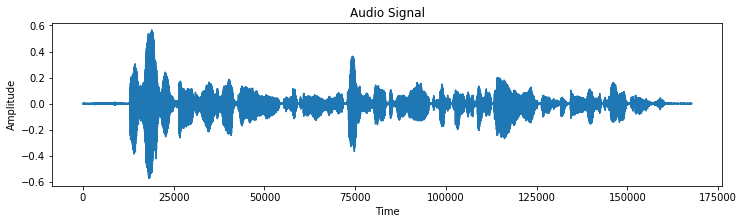

**Shape of Audio Signal** : (167691,)

**Transcript** : the houses seemed miserable in the extreme especially to an eye accustomed to the smiling neatness of english cottages

[interactive chart not shown]

```python
from IPython.display import Markdown, display
from data_generator import vis_train_features, plot_raw_audio
from IPython.display import Audio
%matplotlib inline

# plot audio signal
plot_raw_audio(vis_raw_audio)
# print length of audio signal
display(Markdown('**Shape of Audio Signal** : ' + str(vis_raw_audio.shape)))
# print transcript corresponding to audio clip
display(Markdown('**Transcript** : ' + str(vis_text)))
# play the audio file
Audio(vis_audio_path)
```

## STEP 1: Acoustic Features for Speech Recognition

For this project, I first performs a pre-processing step to convert the raw audio to a feature representation that has historically proven successful for ASR models. My acoustic model will accept the feature representation as input.

I will explore two possible feature representations.[research paper](https://pdfs.semanticscholar.org/a566/cd4a8623d661a4931814d9dffc72ecbf63c4.pdf).

### Spectrograms

The first option for an audio feature representation is the [spectrogram](https://www.youtube.com/watch?v=_FatxGN3vAM). the code for calculating the spectrogram was borrowed from [this repository](https://github.com/baidu-research/ba-dls-deepspeech). The implementation appears in the `utils.py` file in the repository.

The code returns the spectrogram as a 2D tensor, where the first (*vertical*) dimension indexes time, and the second (*horizontal*) dimension indexes frequency. To speed the convergence of the algorithm, I have also normalized the spectrogram. (See this quickly in the visualization below by noting that the mean value hovers around zero, and most entries in the tensor assume values close to zero.)

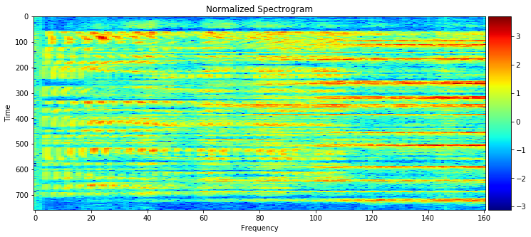

**Shape of Spectrogram** : (759, 161)

```python
from data_generator import plot_spectrogram_feature

# plot normalized spectrogram
plot_spectrogram_feature(vis_spectrogram_feature)
# print shape of spectrogram
display(Markdown('**Shape of Spectrogram** : ' + str(vis_spectrogram_feature.shape)))
```

### Mel-Frequency Cepstral Coefficients (MFCCs)

The second option for an audio feature representation is [MFCCs](https://en.wikipedia.org/wiki/Mel-frequency_cepstrum). The details of how MFCCs are calculated [documentation](https://github.com/jameslyons/python_speech_features) of the `python_speech_features` Python package. Just as with the spectrogram features, the MFCCs are normalized in the supplied code.

The main idea behind MFCC features is the same as spectrogram features: at each time window, the MFCC feature yields a feature vector that characterizes the sound within the window. Note that the MFCC feature is much lower-dimensional than the spectrogram feature, which could help an acoustic model to avoid overfitting to the training dataset.

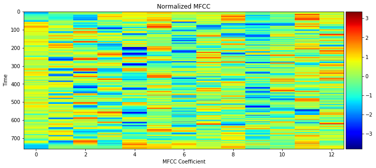

**Shape of MFCC** : (759, 13)

```python
from data_generator import plot_mfcc_feature

# plot normalized MFCC
plot_mfcc_feature(vis_mfcc_feature)
# print shape of MFCC
display(Markdown('**Shape of MFCC** : ' + str(vis_mfcc_feature.shape)))
```

## STEP 2: Deep Neural Networks for Acoustic Modeling

In this section, I experiment with various neural network architectures for acoustic modeling.

All models are specified in the `sample_models.py` file.

```python
# allocate 50% of GPU memory
from keras.backend.tensorflow_backend import set_session
import tensorflow as tf
config = tf.ConfigProto()
config.gpu_options.per_process_gpu_memory_fraction = 0.5
set_session(tf.Session(config=config))

# watch for any changes in the sample_models module, and reload it automatically
%load_ext autoreload
%autoreload 2
# import NN architectures for speech recognition
from sample_models import *
# import function for training acoustic model
from train_utils import train_model
```

### Model 0: RNN

Given their effectiveness in modeling sequential data, the first acoustic model I use is an RNN. As shown in the figure below, the RNN takes the time sequence of audio features as input.

[figure not shown]

At each time step, the speaker pronounces one of 28 possible characters, including each of the 26 letters in the English alphabet, along with a space character (" "), and an apostrophe (').

The output of the RNN at each time step is a vector of probabilities with 29 entries, where the $i$-th entry encodes the probability that the $i$-th character is spoken in the time sequence. (The extra 29th character is an empty "character" used to pad training examples within batches containing uneven lengths.) The `char_map.py` file in the repository descreibes how characters are mapped to indices in the probability vector. The figure below shows an equivalent, rolled depiction of the RNN that shows the output layer in greater detail.

[figure not shown]

```python
model_0 = simple_rnn_model(input_dim=161)
```

```
_________________________________________________________________
Layer (type)                 Output Shape              Param #
=================================================================
the_input (InputLayer)       (None, None, 161)         0
_________________________________________________________________
rnn (GRU)                    (None, None, 29)          16617
_________________________________________________________________
softmax (Activation)         (None, None, 29)          0
=================================================================
Total params: 16,617
Trainable params: 16,617
Non-trainable params: 0
_________________________________________________________________
None
```

As explored in the lesson, I train the acoustic model with the [CTC loss](http://www.cs.toronto.edu/~graves/icml_2006.pdf) criterion. Custom loss functions take a bit of hacking in Keras. For the implementation details, look at the `add_ctc_loss` function within the `train_utils.py` file in the repository.

To train the architecture, I use the `train_model` function within the `train_utils` module; it has already been imported in one of the above code cells. The `train_model` function takes three **required** arguments:

- `input_to_softmax` - a Keras model instance.
- `pickle_path` - the name of the pickle file where the loss history will be saved.
- `save_model_path` - the name of the HDF5 file where the model will be saved.

There are several **optional** arguments about the training process.

- `minibatch_size` - the size of the minibatches that are generated while training the model (default: `20`).
- `spectrogram` - Boolean value dictating whether spectrogram (`True`) or MFCC (`False`) features are used for training (default: `True`).
- `mfcc_dim` - the size of the feature dimension to use when generating MFCC features (default: `13`).
- `optimizer` - the Keras optimizer used to train the model (default: `SGD(lr=0.02, decay=1e-6, momentum=0.9, nesterov=True, clipnorm=5)`).
- `epochs` - the number of epochs to use to train the model (default: `20`). If you choose to modify this parameter, make sure that it is *at least* 20.
- `verbose` - controls the verbosity of the training output in the `model.fit_generator` method (default: `1`).
- `sort_by_duration` - Boolean value dictating whether the training and validation sets are sorted by (increasing) duration before the start of the first epoch (default: `False`).

The `train_model` function defaults to using spectrogram features; For these features, note that the acoustic model in `simple_rnn_model` should have `input_dim=161`. Otherwise, for MFCC features, the acoustic model should have `input_dim=13`.

I choose to use `GRU` units in the supplied RNN and experiment with `LSTM` or `SimpleRNN` cells. When I change the `GRU` units to `SimpleRNN` cells in `simple_rnn_model`, I notice that the loss quickly becomes undefined (`nan`) - This is due to the [exploding gradients problem](http://www.wildml.com/2015/10/recurrent-neural-networks-tutorial-part-3-backpropagation-through-time-and-vanishing-gradients/). I also implement [gradient clipping](https://arxiv.org/pdf/1211.5063.pdf) in the optimizer to avoid this issue.

```python
train_model(input_to_softmax=model_0,
            pickle_path='model_0.pickle',
            save_model_path='model_0.h5',
            spectrogram=True) # change to for MFCC features
```

### (IMPLEMENTATION) Model 1: RNN + TimeDistributed Dense

After reading about the [TimeDistributed](https://keras.io/layers/wrappers/) wrapper and the [BatchNormalization](https://keras.io/layers/normalization/) layer in the Keras documentation, I add [batch normalization](https://arxiv.org/pdf/1510.01378.pdf) to the recurrent layer to reduce training times. The `TimeDistributed` layer is used to find more complex patterns in the dataset. The unrolled snapshot of the architecture is depicted below.

[figure not shown]

The next figure shows an equivalent, rolled depiction of the RNN that shows the (`TimeDistrbuted`) dense and output layers in greater detail.

[figure not shown]

The RNN function specifies an architecture that satisfies the following requirements:

- The first layer of the neural network should be an RNN (`SimpleRNN`, `LSTM`, or `GRU`) that takes the time sequence of audio features as input. I used `GRU` units here, but also change `GRU` to `SimpleRNN` or `LSTM` to experiment.
- Whereas the architecture in `simple_rnn_model` treated the RNN output as the final layer of the model, I use the output of my RNN as a hidden layer. I use `TimeDistributed` to apply a `Dense` layer to each of the time steps in the RNN output and ensure that each `Dense` layer has `output_dim` units.

```python
model_1 = rnn_model(input_dim=161, # change to 13 for MFCC features
                    units=200,
                    activation='relu')
```

```
_________________________________________________________________
Layer (type)                 Output Shape              Param #
=================================================================
the_input (InputLayer)       (None, None, 161)         0
_________________________________________________________________
rnn (GRU)                    (None, None, 200)         217200
_________________________________________________________________
bn_rnn (BatchNormalization)  (None, None, 200)         800
_________________________________________________________________
time_distributed_2 (TimeDist (None, None, 29)          5829
_________________________________________________________________
softmax (Activation)         (None, None, 29)          0
=================================================================
Total params: 223,829
Trainable params: 223,429
Non-trainable params: 400
_________________________________________________________________
None
```

The code cell below is to train the neural network that I specified in `input_to_softmax`. After the model has finished training, the model is [saved](https://keras.io/getting-started/faq/#how-can-i-save-a-keras-model) in the HDF5 file `model_1.h5`. The loss history is [saved](https://wiki.python.org/moin/UsingPickle) in `model_1.pickle`.

```python
train_model(input_to_softmax=model_1,
            pickle_path='model_1.pickle',
            save_model_path='model_1.h5',
            spectrogram=True) # change to False for MFCC features
```

### (IMPLEMENTATION) Model 2: CNN + RNN + TimeDistributed Dense

The architecture in `cnn_rnn_model` adds an additional level of complexity, by introducing a [1D convolution layer](https://keras.io/layers/convolutional/#conv1d).

[figure not shown]

This layer incorporates many arguments that can be (optionally) tuned when calling the `cnn_rnn_model` module.

When tuning the parameters, I avoid to choose settings that make the convolutional layer overly small and make sure the temporal length of the CNN layer is not shorter than the length of the transcribed text label.

```python
model_2 = cnn_rnn_model(input_dim=161, # change to 13 for MFCC features
                        filters=200,
                        kernel_size=11,
                        conv_stride=2,
                        conv_border_mode='valid',
                        units=200)
```

```
_________________________________________________________________
Layer (type)                 Output Shape              Param #
=================================================================
the_input (InputLayer)       (None, None, 161)         0
_________________________________________________________________
conv1d (Conv1D)              (None, None, 200)         354400
_________________________________________________________________
bn_conv_1d (BatchNormalizati (None, None, 200)         800
_________________________________________________________________
rnn (SimpleRNN)              (None, None, 200)         80200
_________________________________________________________________
bn_rnn_1d (BatchNormalizatio (None, None, 200)         800
_________________________________________________________________
time_distributed_1 (TimeDist (None, None, 29)          5829
_________________________________________________________________
softmax (Activation)         (None, None, 29)          0
=================================================================
Total params: 442,029
Trainable params: 441,229
Non-trainable params: 800
_________________________________________________________________
None
```

The code cell below is to train the neural network you specified in `input_to_softmax`. After the model has finished training, the model is [saved](https://keras.io/getting-started/faq/#how-can-i-save-a-keras-model) in the HDF5 file `model_2.h5`. The loss history is [saved](https://wiki.python.org/moin/UsingPickle) in `model_2.pickle`.

```python
train_model(input_to_softmax=model_2,
            pickle_path='model_2.pickle',
            save_model_path='model_2.h5',
            spectrogram=True) # change to False for MFCC features
```

### (IMPLEMENTATION) Model 3: Deeper RNN + TimeDistributed Dense

The code in `rnn_model`makes use of a single recurrent layer. I specify an architecture in `deep_rnn_model` that utilizes a variable number `recur_layers` of recurrent layers. The figure below shows the architecture that should be returned if `recur_layers=2`. In the figure, the output sequence of the first recurrent layer is used as input for the next recurrent layer.

[figure not shown]

```python
model_3 = deep_rnn_model(input_dim=161, # change to 13 for MFCC features
                         units=200,
                         recur_layers=2)
```

```
_________________________________________________________________
Layer (type)                 Output Shape              Param #
=================================================================
the_input (InputLayer)       (None, None, 161)         0
_________________________________________________________________
rnn_0 (GRU)                  (None, None, 200)         217200
_________________________________________________________________
bn_conv_0 (BatchNormalizatio (None, None, 200)         800
_________________________________________________________________
rnn_1 (GRU)                  (None, None, 200)         240600
_________________________________________________________________
bn_conv_1 (BatchNormalizatio (None, None, 200)         800
_________________________________________________________________
time_distributed_1 (TimeDist (None, None, 29)          5829
_________________________________________________________________
softmax (Activation)         (None, None, 29)          0
=================================================================
Total params: 465,229
Trainable params: 464,429
Non-trainable params: 800
_________________________________________________________________
None
```

The code cell below to train the neural network you specified in `input_to_softmax`. After the model has finished training, the model is [saved](https://keras.io/getting-started/faq/#how-can-i-save-a-keras-model) in the HDF5 file `model_3.h5`. The loss history is [saved](https://wiki.python.org/moin/UsingPickle) in `model_3.pickle`.

```python
train_model(input_to_softmax=model_3,
            pickle_path='model_3.pickle',
            save_model_path='model_3.h5',
            spectrogram=True) # change to False for MFCC features
```

### (IMPLEMENTATION) Model 4: Bidirectional RNN + TimeDistributed Dense

After reading about the [Bidirectional](https://keras.io/layers/wrappers/) wrapper in the Keras documentation, I specify an architecture that uses a single bidirectional RNN layer, before a (`TimeDistributed`) dense layer. The added value of a bidirectional RNN is described well in [this paper](http://www.cs.toronto.edu/~hinton/absps/DRNN_speech.pdf).

> One shortcoming of conventional RNNs is that they are only able to make use of previous context. In speech recognition, where whole utterances are transcribed at once, there is no reason not to exploit future context as well. Bidirectional RNNs (BRNNs) do this by processing the data in both directions with two separate hidden layers which are then fed forwards to the same output layer.

[figure not shown]

```python
model_4 = bidirectional_rnn_model(input_dim=161, # change to 13 for MFCC features
                                  units=200)
```

```
_________________________________________________________________
Layer (type)                 Output Shape              Param #
=================================================================
the_input (InputLayer)       (None, None, 161)         0
_________________________________________________________________
bidirectional_1 (Bidirection (None, None, 400)         434400
_________________________________________________________________
time_distributed_1 (TimeDist (None, None, 29)          11629
_________________________________________________________________
softmax (Activation)         (None, None, 29)          0
=================================================================
Total params: 446,029
Trainable params: 446,029
Non-trainable params: 0
_________________________________________________________________
None
```

The code cell below is to train the neural network you specified in `input_to_softmax`. After the model has finished training, the model is [saved](https://keras.io/getting-started/faq/#how-can-i-save-a-keras-model) in the HDF5 file `model_4.h5`. The loss history is [saved](https://wiki.python.org/moin/UsingPickle) in `model_4.pickle`.

```python
train_model(input_to_softmax=model_4,
            pickle_path='model_4.pickle',
            save_model_path='model_4.h5',
            spectrogram=True) # change to False for MFCC features
```